# hvCpG_BayesAlgo

Alice Balard

2025-04-30

```r
knitr::opts_chunk$set(echo = TRUE)
library(dplyr)
library(data.table)
library(matrixStats)
```

```r
library(ggplot2)
library(reshape2)
library(ggrepel)
```

# Data prep

```r
##########################################################################################
## LSHTM: Maria’s data that she used for the hvCpG paper can be accessed from ing-p5 here:
# /mnt/old_user_accounts/p3/maria/PhD/Data/datasets/
#
# Her hvCpG scripts are here:
# /mnt/old_user_accounts/p3/maria/PhD/Projects/hvCpGs/Scripts/

MariasCpGs <- read.csv("~/2024_hvCpG/Derakhshan2022_ST5_hvCpG.txt")

folder1 <- "/mnt/old_user_accounts/p3/maria/PhD/Data/datasets/GEO/BMIQ + 10 PCs + age + sex OUTLIERS REMOVED/"
folder1 <- normalizePath("/mnt/old_user_accounts/p3/maria/PhD/Data/datasets/GEO/BMIQ + 10 PCs + age + sex OUTLIERS REMOVED/")
rds_files1 <- list.files(path = folder1, pattern = "\\.RDS$", full.names = TRUE)

# Read all .rds files into a list and convert each to a matrix
rds_list_mat1 <- lapply(rds_files1, function(file) {
  as.matrix(readRDS(file))
})
## Name the list elements by file names (without extensions)
names(rds_list_mat1) <- gsub("\\.RDS$", "", basename(rds_files1))

rds_list_mat2 <- readRDS("/mnt/old_user_accounts/p3/maria/PhD/Data/datasets/TCGA/TCGA_BMIQ_age_sex_PC_adjusted_OUTLIERS_REMOVED_round2.RDS")
rds_list_mat2 <- lapply(rds_list_mat2, function(x) {
  as.matrix(x)
})

rds_list_mat <- c(rds_list_mat1, rds_list_mat2)

# Keep only the array background (covered in 15 datasets out of 30)
all_cpgs <- unlist(lapply(rds_list_mat, rownames))
cpg_counts <- table(all_cpgs)
common_cpgs <- names(cpg_counts[cpg_counts >= 15])

filtered_list_mat <- lapply(rds_list_mat, function(mat) {
  mat[rownames(mat) %in% common_cpgs, ]
})

rm(rds_list_mat1,rds_list_mat2, rds_list_mat)
```

# Reproduce Maria’s results

Maria’s paper: We defined an hvCpG in the following way:

1. in 65% of datasets in which the CpG is covered (following quality control), it has methylation variance in the top 5% of all (non-removed) CpGs.
2. is covered in at least 15 of the 30 datasets.

```r
## Within each dataset, calculate the CpGs variance, and keep the top 5%
top5pcvar <- lapply(filtered_list_mat, function(mat) {
  # Step 1: Calculate row variances
  row_variances = rowVars(mat, na.rm = T)
  df = data.frame(var=row_variances, cpg=names(row_variances))
  # Step 2
  top = top_n(df, as.integer(0.05*nrow(df)), var) ## slightly different than quantile cause keep ties
  return(top)
})

## CpGs in the top 5% variance:
cpg_counts_top <- table(unlist(lapply(top5pcvar, rownames))) %>%
  data.frame() %>% dplyr::rename("cpgs"="Var1", "all_cpgs_top5pc"="Freq")

## all covered CpGs:
cpg_counts <- table(unlist(lapply(filtered_list_mat, rownames))) %>%
  data.frame() %>% dplyr::rename("cpgs"="Var1", "all_cpgs"="Freq")

## Both:
cpg_counts_full <- merge(cpg_counts, cpg_counts_top, all.x = T)
rm(cpg_counts, cpg_counts_top)

## in 65% of datasets in which the CpG is covered (following quality control), it has methylation variance in the top 5% of all (non-removed) CpGs:
hvCpGs_maria <- na.omit(cpg_counts_full[cpg_counts_full$all_cpgs_top5pc/cpg_counts_full$all_cpgs >= 0.65,])

## rounding, to mimick Maria's approach
hvCpGs_maria <- na.omit(cpg_counts_full[round(cpg_counts_full$all_cpgs_top5pc/cpg_counts_full$all_cpgs, 2) >= 0.65,])
```

Maria detected 4143 hvCpGs. I detected 4377 hvCpGs. We both have 4143 hvCpGs in common.

# Identify hvCpGs based on a sd multiplicative factor lambda

The proportion of CpGs than Maria found hvCpGs is p(hvCpG) = 1.02%.

## Calculate lambda

Within each dataset k, calculate the median sd of all CpG j

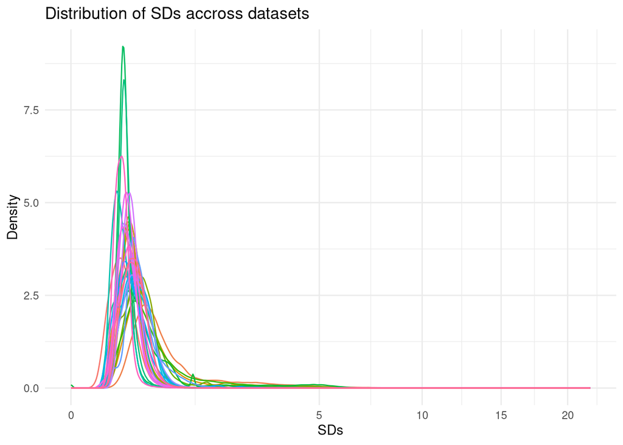

```r
all_sd_jk <- sapply(filtered_list_mat, function(k){

  ## Scale
  k = log2(k/(1-k))

  get_sd_k <- function(k){
    ## Calculate a vector of the row (=per CpG j) sd
    return(rowSds(k, na.rm = T))
  }
  ## Return a vector of sds, in a list for each dataset
  return(get_sd_k(k))
})

## Plot:
df_long <- reshape2::melt(all_sd_jk, variable.name = "Vector", value.name = "SDs")

## Plot distributions of all vectors on the same graph
ggplot(df_long, aes(x = SDs, color = L1)) +
  geom_density() +
  labs(title = "Distribution of SDs accross datasets",
       x = "SDs",
       y = "Density") +
  theme_minimal() +
  theme(legend.position = "none") +
  scale_x_sqrt()
```

```r
## Calculate lambda per dataset
lambdas = sapply(all_sd_jk, function(x){quantile(x, 0.95, na.rm=T)/median(x, na.rm=T)})
names(lambdas) <- gsub(".95%", "", names(lambdas))
```

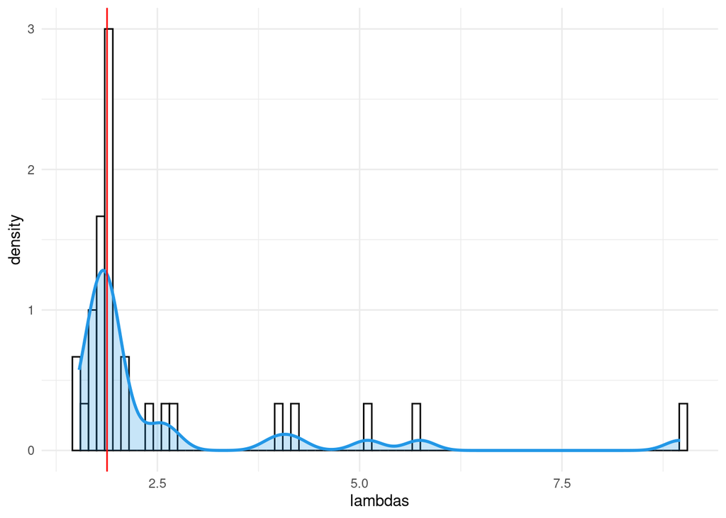

```r
# Histogram with kernel density
ggplot(data.frame(lambda=lambdas, dataset=names(lambdas)),
       aes(x = lambdas)) +
  geom_histogram(aes(y = after_stat(density)),
                 colour = 1, fill = "white", binwidth = .1) +
  geom_density(lwd = 1, colour = 4,
               fill = 4, alpha = 0.25)+
  theme_minimal() +
  geom_vline(xintercept = median(lambdas), col = "red")
```

```r
median(lambdas) #1.878303
```

```
## [1] 1.878303
```

Which datasets have a higher lambda, and why?

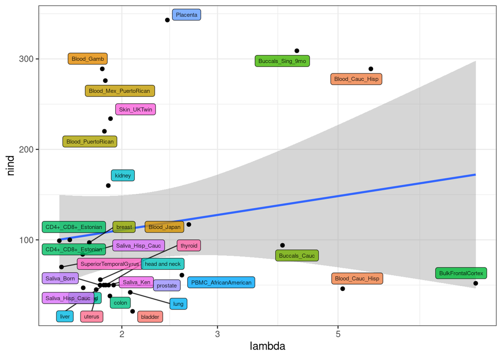

```r
df = data.frame(nind=sapply(filtered_list_mat, ncol),
                dataset=names(filtered_list_mat),
                lambda=lambdas,
                tissue = sapply(strsplit(names(filtered_list_mat), "_"), `[`, 1),
                ethnicity=sapply(strsplit(names(filtered_list_mat), "_"), `[`, 2)) %>%
  mutate(dataset=ifelse(dataset %in% c("Blood_Cauc", "Blood_Hisp"), "Blood_Cauc_Hisp", dataset)) %>%
  mutate(dataset=ifelse(dataset %in% c("Blood_Mexican", "Blood_PuertoRican "), "Blood_Mex_PuertoRican ", dataset)) %>%
  mutate(dataset=ifelse(dataset %in% c("CD4+_Estonian", "CD8+_Estonian"), "CD4+_CD8+_Estonian", dataset)) %>%
  mutate(dataset=ifelse(dataset %in% c("Saliva_Hisp", "Saliva_Cauc"), "Saliva_Hisp_Cauc", dataset))

ggplot(data = df,
       aes(x=lambda, y=nind))+
  geom_smooth(method = "lm")+
  geom_point()+
  geom_label_repel(aes(label = dataset, fill=dataset), size= 2, alpha=.8, max.overlaps = 25)+
  theme_bw()+theme(legend.position = "none")+
  scale_x_log10()
```

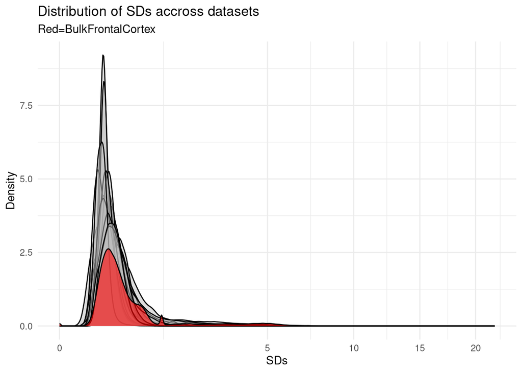

```r
## Emphasize the outliers
df_long$col = "grey"
df_long$col[df_long$L1 %in% "BulkFrontalCortex"] <- "red"

ggplot(df_long, aes(x = SDs, group = L1, fill = col)) +
  geom_density(data = df_long[!df_long$L1 %in% "BulkFrontalCortex",], alpha = .5) +
  geom_density(data = df_long[df_long$L1 %in% "BulkFrontalCortex",], alpha = .6) +
  scale_fill_manual(values = c("grey", "red"))+
  labs(title = "Distribution of SDs accross datasets",subtitle = "Red=BulkFrontalCortex",
       x = "SDs",
       y = "Density") +
  theme_minimal() +
  theme(legend.position = "none") +
  scale_x_sqrt()
```

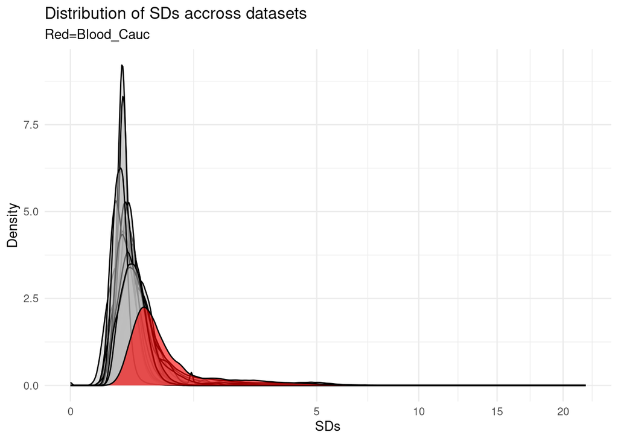

```r
## Emphasize the outliers
df_long$col = "grey"
df_long$col[df_long$L1 %in% "Blood_Cauc"] <- "red"

ggplot(df_long, aes(x = SDs, group = L1, fill = col)) +
  geom_density(data = df_long[!df_long$L1 %in% "Blood_Cauc",], alpha = .5) +
  geom_density(data = df_long[df_long$L1 %in% "Blood_Cauc",], alpha = .6) +
  scale_fill_manual(values = c("grey", "red"))+
  labs(title = "Distribution of SDs accross datasets",subtitle = "Red=Blood_Cauc",
       x = "SDs",
       y = "Density") +
  theme_minimal() +
  theme(legend.position = "none") +
  scale_x_sqrt()
```

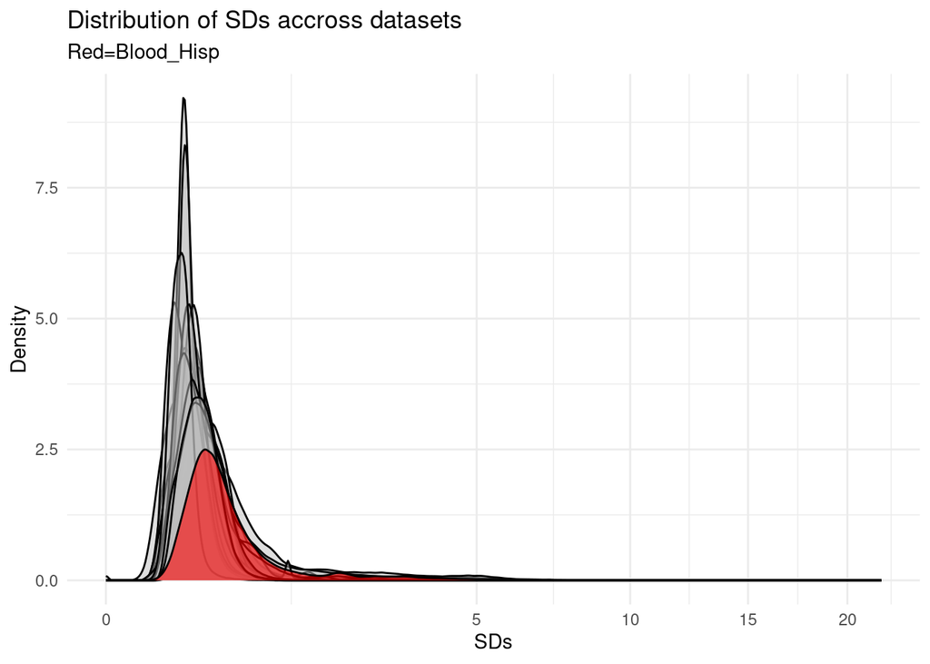

```r
## Emphasize the outlier
df_long$col = "grey"
df_long$col[df_long$L1 %in% "Blood_Hisp"] <- "red"

ggplot(df_long, aes(x = SDs, group = L1, fill = col)) +
  geom_density(data = df_long[!df_long$L1 %in% "Blood_Hisp",], alpha = .5) +
  geom_density(data = df_long[df_long$L1 %in% "Blood_Hisp",], alpha = .6) +
  scale_fill_manual(values = c("grey", "red"))+
  labs(title = "Distribution of SDs accross datasets",subtitle = "Red=Blood_Hisp",
       x = "SDs",
       y = "Density") +
  theme_minimal() +
  theme(legend.position = "none") +
  scale_x_sqrt()
```

# Maximum likelihood analysis

The equation is:

$$\log\left(P(M_j)\right) = \sum_{i=1}^{n} \log\left( \sum_{Z_j=0}^{1}
\left( \sum_{Z_{j,k}=0}^{1} P(M_{i,j} \mid Z_{j,k}) \times P(Z_{j,k}
\mid Z_j) \right) \times P(Z_j) \right)$$

## Functions to calculate different parameters of the datasets:

These functions take as imput “our_list_datasets”, a list of matrices containing our datasets

It outputs * scaled_list_mat: a list of scaled matrices * mu_jk: named list for each dataset of vectors containing the mean methylation for each CpG j * sigma_k: named list for each dataset of elements = the median sd for all CpGs

```r
get_scaled_list_mat <- function(our_list_datasets){
  lapply(our_list_datasets, function(k){ ## Scale all the datasets in list
    k = log2(k/(1-k))
  })
}

get_mu_jk_list <- function(scaled_list_mat){
  lapply(scaled_list_mat, function(k){rowMeans(k, na.rm = T)}) ## list of mean methylation for each CpG j in all datasets
}

get_sigma_k_list <- function(scaled_list_mat){
  lapply(scaled_list_mat, function(k){
    sd_j <- rowSds(k, na.rm = T)  ## Calculate the row (=per CpG j) sd
    return(median(sd_j, na.rm = T))  ## Calculate the median sd in dataset k
  })
}

get_lambda_k_list <- function(scaled_list_mat) {
  # Calculate row SDs for each dataset matrix
  all_sd_jk <- sapply(scaled_list_mat, matrixStats::rowSds, na.rm = TRUE)
  # Compute lambda values (95th percentile / median) for each dataset
  lambdas <- sapply(all_sd_jk, \(x) quantile(x, 0.95, na.rm = TRUE) / median(x, na.rm = TRUE))
  # Clean names and return
  names(lambdas) <- gsub(".95%", "", names(lambdas))
  return(lambdas)
}
```

## Likelihood function for a given CpG j

The arguments are: * listMat: a list of matrices, i.e. our datasets

For the function to optimise itself: * j: a CpG (default=first CpG) * lambdas: a vector of lambda, one per dataset (multiplicative factor of the sd_k for hvCpG) * p0: proba of true negative * p1: proba of true positive * alpha: probability of a CpG site to be a hvCpG

```r
## Prepare our data in general environment:
scaled_list_mat <- get_scaled_list_mat(filtered_list_mat)
mu_jk_list <- get_mu_jk_list(scaled_list_mat)
sigma_k_list <- get_sigma_k_list(scaled_list_mat)
lambdas <- get_lambda_k_list(scaled_list_mat)

getLogLik_oneCpG_optimized <- function(scaled_list_mat, mu_jk_list, sigma_k_list,
                                       j, p0, p1, alpha, lambdas) {

  # Ensure the number of lambda parameters matches scaled_list_mat's length
  if (length(lambdas) != length(scaled_list_mat)) {
    stop("Number of lambda arguments must match length(scaled_list_mat)")
  }

  # Precompute all necessary values upfront
  datasets <- names(scaled_list_mat)
  log_P_Mj <- 0 ## initialise

  # Precompute probability matrices
  p0p1_mat <- matrix(c(p0, 1-p1, 1-p0, p1), nrow=2, byrow=TRUE)

  proba_hvCpG_vec <- c(1-alpha, alpha)

  for (k in datasets) {

    # 1. SAFE ROW INDEXING
    row_idx <- which(rownames(scaled_list_mat[[k]]) == j)
    if (length(row_idx) == 0) next  # Skip missing CpGs

    # 2. SAFE VALUE EXTRACTION
    Mij_vals <- tryCatch({
      scaled_list_mat[[k]][row_idx, ]
    }, error = function(e) numeric(0))

    # Remove NAs and check length
    Mij_vals <- Mij_vals[!is.na(Mij_vals)]
    if (length(Mij_vals) == 0) next

    # 3. MISSING VALUE HANDLING FOR MU
    mu_jk <- mu_jk_list[[k]][j]
    if (is.na(mu_jk)) {
      warning(paste("Missing mu_jk for", j, "in dataset", k))
      next
    }

    # 4. SAFE STANDARD DEVIATION
    sd_k <- sigma_k_list[[k]]
    if (is.na(sd_k) || sd_k <= 0) {
      warning(paste("Invalid sd_k for dataset", k))
      next
    }

    # 5. LAMBDA VALIDATION
    lambda_k <- lambdas[k]
    if (is.na(lambda_k) || lambda_k <= 0) {
      warning(paste("Invalid lambda_k for dataset", k))
      next
    }

    # 6. VECTORIZED CALCULATIONS WITH CHECKS
    sd_values <- c(sd_k, lambda_k * sd_k)
    if (any(is.na(sd_values)) || any(sd_values <= 0)) {
      warning(paste("Invalid sd_values for", j, "in dataset", k))
      next
    }

    # 7. PROBABILITY CALCULATIONS: proba(M(i,j) knowing Z(j,k) 0 or 1)
    # a matrix of 2 columns (sd or lambda sd), one row per individual
    norm_probs <- tryCatch({
      matrix(c(
        dnorm(Mij_vals, mu_jk, sd_values[1]),
        dnorm(Mij_vals, mu_jk, sd_values[2])
      ), ncol=2)
    }, error = function(e) {
      warning(paste("DNORM error for", j, "in dataset", k))
      matrix(1, nrow=length(Mij_vals), ncol=2)  # Fallback to neutral values
    })

    # 8. ARRAY OPERATIONS: double the previous matrix to create two, for Zj=0 or 1
    zjk_probs <- array(dim = c(length(Mij_vals), 2, 2))
    for (zjk in 0:1) {
      zjk_probs[,,zjk+1] <- cbind(norm_probs[, zjk+1] * p0p1_mat[zjk+1, 1],
                                  norm_probs[, zjk+1] * p0p1_mat[zjk+1, 2])
    }
    # zjk_probs[,,1] <- cbind(norm_probs[, 1] * p0p1_mat[1, 1], ## M with sd_k * p0
    #                             norm_probs[, 1] * p0p1_mat[1, 2])## M with sd_k * 1-p1
    # zjk_probs[,,2] <- cbind(norm_probs[, 2] * p0p1_mat[2, 1],## M with lambda_k * sd_k * 1-p0
    #                             norm_probs[, 2] * p0p1_mat[2, 2])## M with lambda_k * sd_k * p1

    # 9. LOGSUMEXP IMPLEMENTATION
    # Sum columns across depth dimension
    col_sums <- apply(zjk_probs, c(1,3), sum)  # c(1,3) applies the function sum to both rows (1) and the third dimension (3)
    # apply(X, c(1,3), sum) = X[,1,] + X[,2,] + X[,3,] = sum of the columns within each row and third dim level
    ## for us, does row sum of
    ## [(M with sd_k * p0) + (M with sd_k * 1-p1)] +
    ## [(M with lambda_k * sd_k * 1-p0) + (M with lambda_k * sd_k * p1)]
    ## Which corresponds to:
    ## P(Mj|Zjk=0) * P(Zjk=0|Zj=0) + P(Mj|Zjk=0) * P(Zjk=0|Zj=1) +
    ## P(Mj|Zjk=1) * P(Zjk=1|Zj=0) + P(Mj|Zjk=1) * P(Zjk=1|Zj=1)
    # Multiply columns proba_hvCpG_vec and sum, then log, then sum for all individuals

    ## How to handle log(0)? We replace -Inf by the next lowest value
    dataset_loglik <- sum(
      ifelse(log(rowSums(col_sums %*% proba_hvCpG_vec))==-Inf,
             min(log(rowSums(col_sums %*% proba_hvCpG_vec))[
               log(rowSums(col_sums %*% proba_hvCpG_vec)) > -10E100]),
             log(rowSums(col_sums %*% proba_hvCpG_vec))))

    if (!is.finite(dataset_loglik)) {
      warning(paste("Non-finite loglik for", j, "in dataset", k))
      dataset_loglik <- 0  # Neutral value for problematic calculations
    }
    # cat("Dataset log likelihood:\n")
    # print(dataset_loglik)
    log_P_Mj <- log_P_Mj + dataset_loglik
  }
  # cat("Sum of all datasets log likelihood:\n")
  return(log_P_Mj)
}

## loglik for one CpG
getLogLik_oneCpG_optimized(scaled_list_mat,
                           mu_jk_list,
                           sigma_k_list,
                           j = common_cpgs[[1]],
                           p0 = 0.95, p1 = 0.65, alpha = 0.01,
                           lambdas) # -421.0793
```

```
## [1] -421.0793
```

```r
getLogLik_oneCpG_optimized(scaled_list_mat,
                           mu_jk_list,
                           sigma_k_list,
                           j = common_cpgs[[1]],
                           p0 = 0.95, p1 = 0.65, alpha = 0.01,
                           lambdas) # -421.0793
```

```
## [1] -421.0793
```

## Examine weird values

The transformation lead to weird values:

```r
filtered_list_mat$Blood_Hisp[rownames(filtered_list_mat$Blood_Hisp) %in% "cg23089912",1:10]
```

```
##   GSM1870950   GSM1870963   GSM1870970   GSM1870971   GSM1870975   GSM1870977
## 8.882523e-03 2.767521e-03 2.575228e-03 7.077626e-04 1.379438e-03 2.837506e-03
##   GSM1870979   GSM1870986   GSM1870989   GSM1870992
## 8.632700e-03 1.124546e-17 2.056392e-03 1.942933e-04
```

```r
scaled_list_mat$Blood_Hisp[rownames(scaled_list_mat$Blood_Hisp) %in% "cg23089912",1:10]
```

```
## GSM1870950 GSM1870963 GSM1870970 GSM1870971 GSM1870975 GSM1870977 GSM1870979
##  -6.801943  -8.493192  -8.597364 -10.463425  -9.499712  -8.457061  -6.843464
## GSM1870986 GSM1870989 GSM1870992
## -56.303435  -8.922699 -12.329196
```

```r
test <- readRDS("/mnt/old_user_accounts/p3/maria/PhD/Data/datasets/GEO/Raw_cleaned_beta_matrices_GEO/Blood_Hisp")
test[rownames(test) %in% "cg23089912",5:10]
```

```
##            GSM1870975 GSM1870977 GSM1870979 GSM1870986 GSM1870989 GSM1870992
## cg23089912  0.8486523  0.8883389  0.8610275          0  0.8572614  0.8153023
```

```r
test <- readRDS("/mnt/old_user_accounts/p3/maria/PhD/Data/datasets/GEO/BMIQ + 10 PCs + age + sex OUTLIERS REMOVED/Blood_Hisp.RDS")
test[rownames(test) %in% "cg23089912",5:10]
```

```
##             GSM1870975  GSM1870977 GSM1870979   GSM1870986  GSM1870989
## cg23089912 0.001379438 0.002837506  0.0086327 1.124546e-17 0.002056392
##              GSM1870992
## cg23089912 0.0001942933
```

```r
# GSM1870986
# 0.00000000000000001124546 --> give extreme value in scaling, and p dnorm=0
```

The zero in 8h sample was weirdly transformed. The cleaned values are very different from the original. Is that expected?

## Loglik for all CpGs

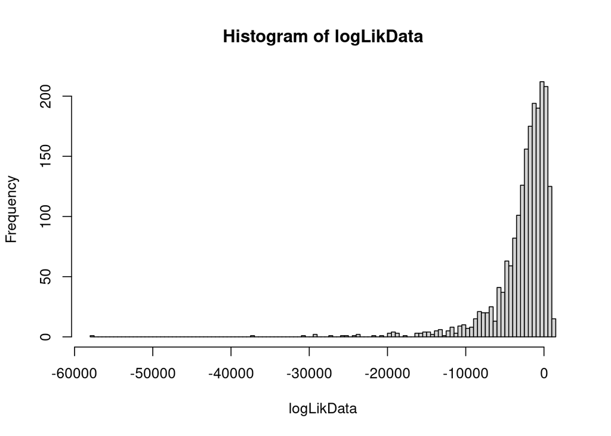

```r
set.seed(1234)
testCpGs20 <- c(sample(common_cpgs[common_cpgs %in% MariasCpGs$CpG], 10),
              sample(common_cpgs[!common_cpgs %in% MariasCpGs$CpG], 10))
testCpGs200 <- c(sample(common_cpgs[common_cpgs %in% MariasCpGs$CpG], 100),
              sample(common_cpgs[!common_cpgs %in% MariasCpGs$CpG], 100))
testCpGs2000 <- c(sample(common_cpgs[common_cpgs %in% MariasCpGs$CpG], 1000),
              sample(common_cpgs[!common_cpgs %in% MariasCpGs$CpG], 1000))

logLikData <- sapply(testCpGs2000,
                     function(x){
                       getLogLik_oneCpG_optimized(scaled_list_mat,
                                                  mu_jk_list,
                                                  sigma_k_list,
                                                  j = x,
                                                  lambdas = lambdas,
                                                  p0 = 0.95, p1 = 0.65, alpha = 0.01)
                     })

hist(logLikData, breaks = 100)
```

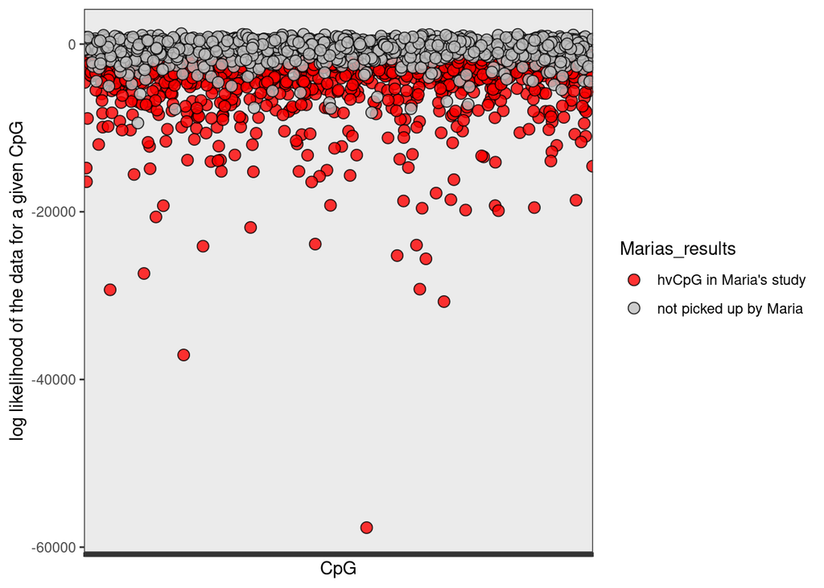

```r
ggplot(data.frame(logLik=logLikData,
                  CpG=names(logLikData),
                  Marias_results = ifelse(names(logLikData) %in% MariasCpGs$CpG, "hvCpG in Maria's study", "not picked up by Maria")),
       aes(x=CpG, y=logLik, fill = Marias_results)) +
  geom_point(pch=21, size = 3, alpha = .8) + scale_fill_manual(values = c("red", "grey"))+
  theme_bw() + theme(axis.text.x = element_blank()) +
  ylab("log likelihood of the data for a given CpG")
```

## Optim to find alpha

https://www.magesblog.com/post/2013-03-12-how-to-use-optim-in-r/

```r
## We optimise over the parameter alpha, and specify everything else

## nb: first argument of getLogLik_oneCpG_optimized must be a vector of parameters over which optimisation takes place
fun2optim <- function(par, scaled_list_mat, mu_jk_list, sigma_k_list, j, p0, p1, lambdas) {
  # Extract alpha
  alpha <- par["alpha"]
  getLogLik_oneCpG_optimized(scaled_list_mat = scaled_list_mat,
                             mu_jk_list = mu_jk_list,
                             sigma_k_list = sigma_k_list,
                             j = j,
                             p0 = p0, p1 = p1, alpha = alpha,
                             lambdas = lambdas)
}

## Check:
getLogLik_oneCpG_optimized(scaled_list_mat = scaled_list_mat,
                           mu_jk_list = mu_jk_list, sigma_k_list = sigma_k_list,
                           j = common_cpgs[[1]], p0 = 0.95, p1 = 0.65, alpha = 0.01,
                           lambdas = lambdas) ==
  fun2optim(par = c(alpha = 0.01), scaled_list_mat = scaled_list_mat,
            mu_jk_list = mu_jk_list, sigma_k_list = sigma_k_list,
            j = common_cpgs[[1]], p0 = 0.95, p1 = 0.65, lambdas = lambdas)
```

```
## [1] TRUE
```

## Optimisation over multiple CpGs

```r
runOptim1CpG <- function(CpG,
                         par_init=c(alpha = 0.5),
                         par_lower=c(alpha = 0),
                         par_upper=c(alpha = 1)){
  # Run optimization
  resOpt <- optim(
    par = par_init,
    fn = fun2optim,
    scaled_list_mat = scaled_list_mat,
    mu_jk_list = mu_jk_list,
    sigma_k_list = sigma_k_list,
    j = CpG, p0 = 0.95, p1 = 0.65, lambdas = lambdas,
    method = "L-BFGS-B",
    lower = par_lower,
    upper = par_upper,
    control = list(fnscale = -1)) # to maximise

  return(resOpt$par)
}

getAllOptimAlpha <- function(cpgvec){
  res = lapply(cpgvec, runOptim1CpG)
  names(res)=cpgvec
  my_matrix <- do.call(rbind, res)
  rownames(my_matrix) <- names(res)
  return(my_matrix)
}
```

## Run the optimisation on a set of CpGs:

```r
system.time(res_allOptimAlpha <- getAllOptimAlpha(cpgvec = testCpGs20))
```

```
##    user  system elapsed
## 115.656   5.759 121.509
```

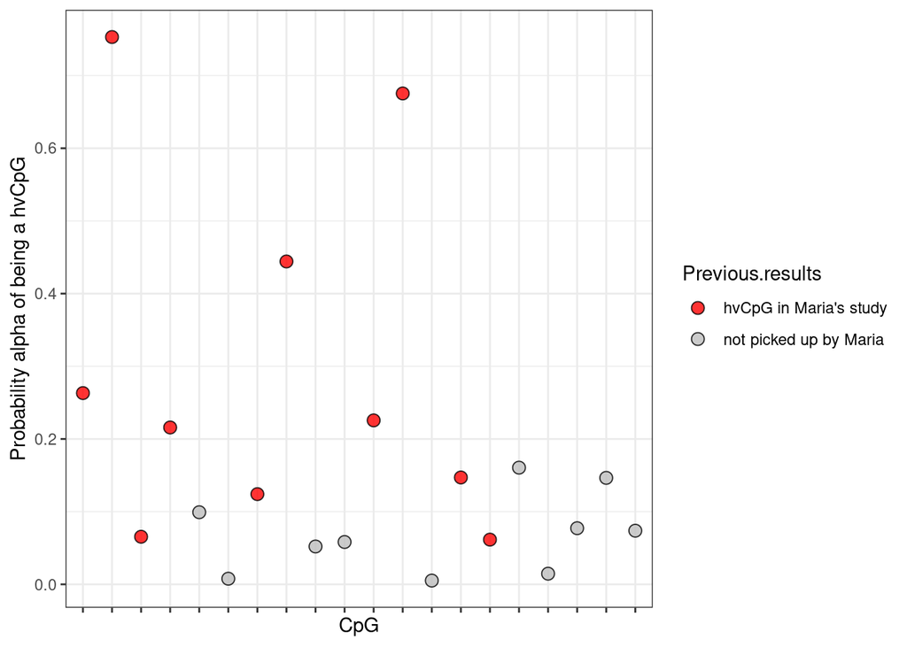

```r
## 1795.180 sec for 200 CpGs
## 400000 *1795.180/200/60/60/24 ## 40 days to run all at this rate

ggplot(data.frame(alpha=res_allOptimAlpha,
                  CpG=rownames(res_allOptimAlpha),
                  Previous.results = ifelse(rownames(res_allOptimAlpha) %in% MariasCpGs$CpG, "hvCpG in Maria's study", "not picked up by Maria")),
       aes(x=CpG, y=alpha, fill = Previous.results)) +
  geom_point(pch=21, size = 3, alpha = .8) + scale_fill_manual(values = c("red", "grey"))+
  theme_bw() + theme(axis.text.x = element_blank()) +
  ylab("Probability alpha of being a hvCpG")
```

```r
library(parallel)
detectCores()
```

```
## [1] 64
```

# Notes:

lambdas are defined based on a 5% threshold, even if alpha is not. How to not hardcode them? MCMC on lambda? Link with alpha?

```r
get_lambda_k_list <- function(scaled_list_mat) {
  # Calculate row SDs for each dataset matrix
  all_sd_jk <- sapply(scaled_list_mat, matrixStats::rowSds, na.rm = TRUE)
  # Compute lambda values (95th percentile / median) for each dataset
  lambdas <- sapply(all_sd_jk, \(x) quantile(x, 0.95, na.rm = TRUE) / median(x, na.rm = TRUE))
  # Clean names and return
  names(lambdas) <- gsub(".95%", "", names(lambdas))
  return(lambdas)
}
```

# The analysis is complete.